# Bioirrigation fitting examples

Emil De Borger

11-6-2021

# Looking at tracer timeseries

Three examples of tracer data from measurements performed in the Dortsman intertidal area (Netherlands).

### First, the data

Uranine concentrations have been converted from FTU’s (raw output of the sensor) to microgram/L using a concentration series performed before the experiment to calibrate the sensors. The time is converted to hours, as that is how the model is set up.

[figure not shown]

### Some corrections

```r
August   <- data.frame("time" = dortsman_data$time, "UrOW" = dortsman_data$August   )
November <- data.frame("time" = dortsman_data$time, "UrOW" = dortsman_data$November )
July     <- data.frame("time" = dortsman_data$time, "UrOW" = dortsman_data$July)

November <- November[-c(1:4),]
November <- November[!(November$time >= 21.4),]
July     <- July[-(1:4),]
```

Now check again:

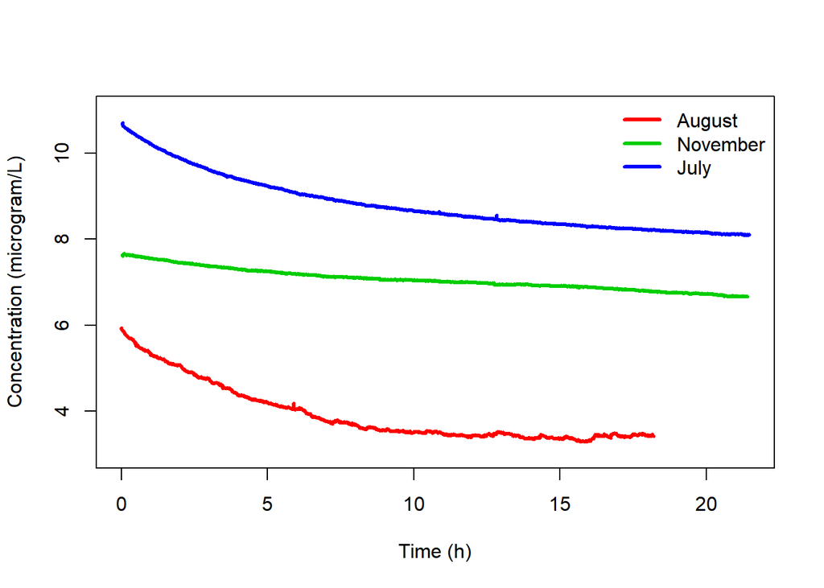

```r
plot(August$time    , August$UrOW   , lwd = 3, col = 2, type = "l", xlab = "Time (h)", ylab = "Concentration (microgram/L)", ylim = c(3, 11))
lines(November$time , November$UrOW , lwd = 3, col = 3)
lines(July$time, July$UrOW, lwd = 3, col = 4)
legend("topright", c("August", "November", "July"), bty = "n", lty = 1, col = 2:4, lwd = 3)
```

# Preparing parameters

```r
# There are three sets of parameters that are specified (in this case).
# Base parameters that are the same in all months.
sediment_parms <- c(kAds = 1, dens = 2.4952, porosity = 0.429, eqAds = .05, pumpSurfDepth = 0.001)

# Parameters specific to each core
August_specific   <- c(hOw = 12  , hSed = 18  , iniConcOW = 5.9293, area = 314.15)
November_specific <- c(hOw = 13.5, hSed = 16.5, iniConcOW = 7.6626, area = 314.15)
July_specific     <- c(hOw = 8.5 , hSed = 21.5, iniConcOW = 10.70263, area = 314.15)

# Combining both
parameters_August    <- c(August_specific  , sediment_parms)
parameters_November  <- c(November_specific, sediment_parms)
parameters_July      <- c(July_specific    , sediment_parms)

# Initial starting parameters for parameters to fit
fitp <- c(pumpSurfRate = 2, pumpSurfAtt = 1)
```

# First run of the model

Without fitting. Now we see why further tuning of the irrigation parameters is necessary.

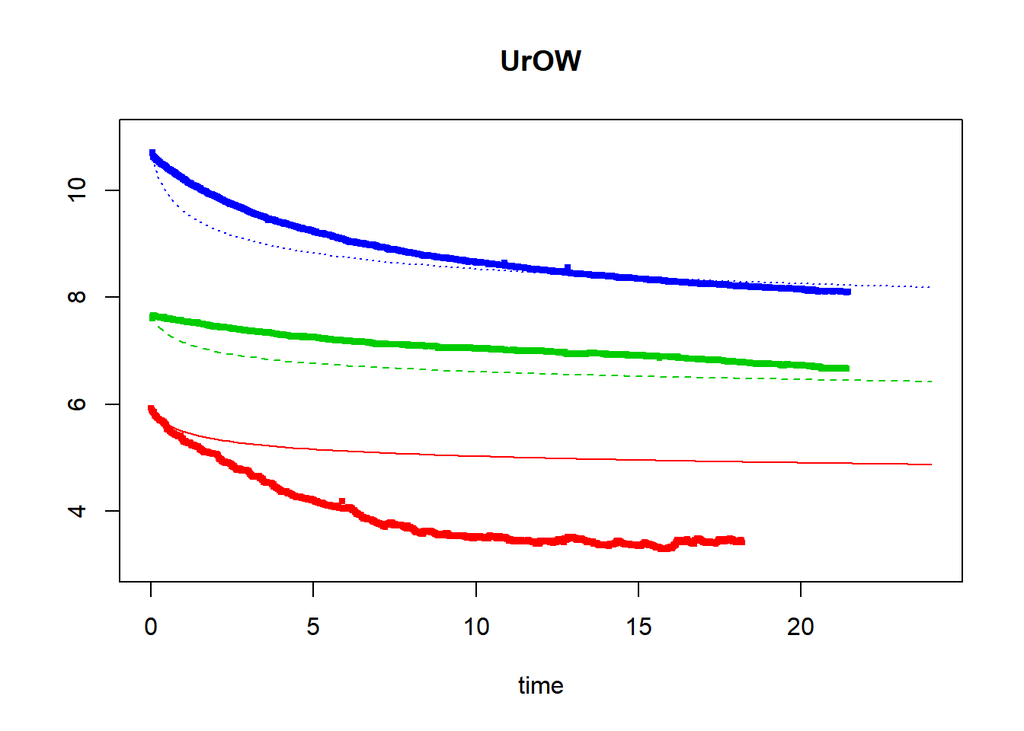

```r
out_August   <- run.Uranine(parms = c(parameters_August  , fitp), hours = 24)
out_November <- run.Uranine(parms = c(parameters_November, fitp), hours = 24)
out_July     <- run.Uranine(parms = c(parameters_July    , fitp), hours = 24)

par(mfrow = c(1,1))
plot(out_August, out_November, out_July, obs = list(August, November, July), col = 2:4, ylim = c(3, 11),
     obspar = list(cex = 4, col = 2:4, pch = "."))
```

# Fitting

- Please check the vignette of the package FME `citation("FME")` to learn more about the fitting procedure used here..

```r
Fit_August    <- modFit(f = URAcost, p = fitp, corepars = parameters_August,
                    measured.data = August, verbose = FALSE,
                    lower=c(0.001, 0.001),
                    upper=c(20, 10),
                    method = "Pseudo",
                    control = list(numiter = 5000))
Fit_November  <- modFit(f = URAcost, p = fitp, corepars = parameters_November,
                    measured.data = November, verbose = FALSE,
                    lower=c(0.001, 0.001),
                    upper=c(5, 10),
                    method = "Pseudo",
                    control = list(numiter = 10000))
Fit_July     <- modFit(f = URAcost, p = fitp, corepars = parameters_July,
                    measured.data = July, verbose = FALSE,
                    lower=c(0.001, 0.001),
                    upper=c(20, 10),
                    method = "Pseudo",
                    control = list(numiter = 10000))
```

# Plot the fitted output

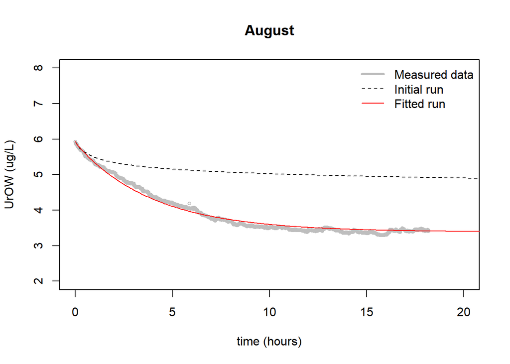

```r
## First run the model with the fitted parameters as input.
final_August   <- run.Uranine(parms = c(coef(Fit_August)  , parameters_August)   , hours = 24, times = seq(from = 0, to = 24, length.out = 288), rtol = 1e-8)
final_November <- run.Uranine(parms = c(coef(Fit_November), parameters_November) , hours = 24, times = seq(from = 0, to = 24, length.out = 288), rtol = 1e-8)
final_July     <- run.Uranine(parms = c(coef(Fit_July)    , parameters_July), hours = 24, times = seq(from = 0, to = 24, length.out = 288), rtol = 1e-8)

plot(August, xlab ="time (hours)", ylab = "UrOW (ug/L)", ylim = c(2,8), xlim = c(0,20), main = "August", cex = 0.6, col = "grey")
lines(out_August[,1], out_August[,2], lty=2)
lines(final_August[,1], final_August[,2], col = 2, lwd = 1)
legend("topright", legend = c("Measured data", "Initial run", "Fitted run"), lty = c(1, 2, 1), col = c("grey",1,2), lwd = c(3,1,1), bty = "n")
```

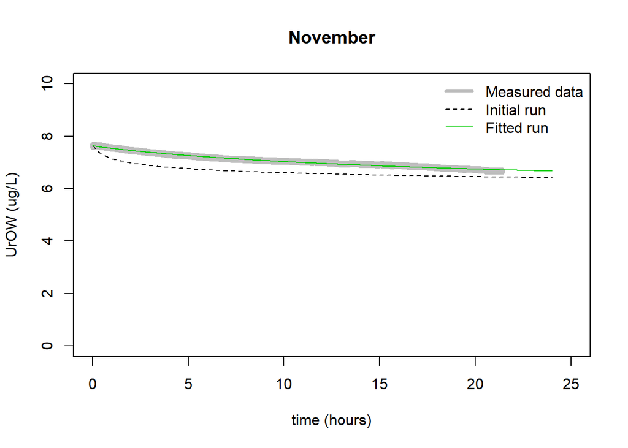

```r
plot(November, xlab ="time (hours)", ylab = "UrOW (ug/L)", ylim = c(0,10), xlim = c(0,25), main = "November", col = "grey")
lines(out_November[,1], out_November[,2], lty=2)
lines(final_November[,1], final_November[,2], col = 3, lwd = 1)
legend("topright", legend = c("Measured data", "Initial run", "Fitted run"), lty = c(1, 2, 1), col = c("grey",1,3), lwd = c(3,1,1), bty = "n")
```

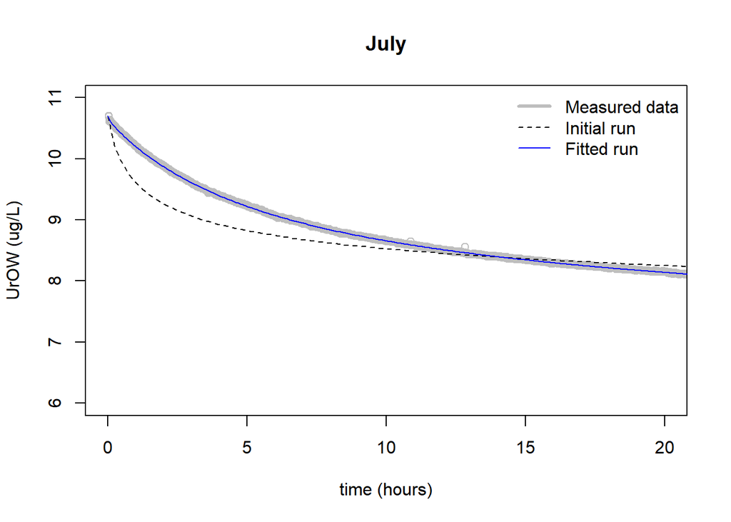

```r
plot(July, xlab ="time (hours)", ylab = "UrOW (ug/L)", ylim = c(6,11), xlim = c(0,20), main = "July", col = "grey")
lines(out_July[,1]  , out_July[,2], lty=2)
lines(final_July[,1], final_July[,2], col = 4, lwd = 1)
legend("topright", legend = c("Measured data", "Initial run", "Fitted run"), lty = c(1, 2, 1), col = c("grey",1,4), lwd = c(3,1,1), bty = "n")
```

# The coefficients

```r
# August
print(coef(Fit_August))
```

```
## pumpSurfRate  pumpSurfAtt
##     1.301865     0.001000
```

```r
# November
print(coef(Fit_November))
```

```
## pumpSurfRate  pumpSurfAtt
##    0.1634816    0.5078954
```

```r
# September
print(coef(Fit_July))
```

```
## pumpSurfRate  pumpSurfAtt
##    0.4087962    0.5373050
```